# CPE Analysis

2023-03-07

## The Center for Policing Equity (CPE)

The Center for Policing Equity (CPE) is a research and policy organization that aims to reduce bias and improve policing practices through data-driven methods. The organization was founded in 2007 by Dr. Phillip Atiba Goff, who is a recognized expert in the field of racial bias in law enforcement.

CPE works with police departments across the United States to collect and analyze data on police interactions with communities of color. The organization’s goal is to use this data to identify and address racial disparities in policing, as well as to develop evidence-based solutions for improving police-community relations.

## Import policing data set of Dallas, Texas in 2016

```r
data <- read.csv("37-00049_UOF-P_2016_prepped.csv")
data = data[-1,]
dim(data)
```

```
## [1] 2383   47
```

The data has 2383 rows and 47 columns about police work in Dallas, Texas in 2016.

There are four types of data found in data set.

### Incident Information

- INCIDENT_DATE
- INCIDENT_TIME
- UOF_NUMBER
- INCIDENT_REASON
- REASON_FOR_FORCE
- TYPE_OF_FORCE_USED1
- TYPE_OF_FORCE_USED2
- TYPE_OF_FORCE_USED3
- TYPE_OF_FORCE_USED4
- TYPE_OF_FORCE_USED5
- TYPE_OF_FORCE_USED6
- TYPE_OF_FORCE_USED7
- TYPE_OF_FORCE_USED8
- TYPE_OF_FORCE_USED9
- TYPE_OF_FORCE_USED10
- NUMBER_EC_CYCLES
- FORCE_EFFECTIVE

### Officer Information

- OFFICER_ID
- OFFICER_GENDER
- OFFICER_RACE
- OFFICER_HIRE_DATE
- OFFICER_YEARS_ON_FORCE
- OFFICER_INJURY
- OFFICER_INJURY_TYPE
- OFFICER_HOSPITALIZATION

### Subject Information

- SUBJECT_ID
- SUBJECT_RACE
- SUBJECT_GENDER
- SUBJECT_INJURY
- SUBJECT_INJURY_TYPE
- SUBJECT_WAS_ARRESTED
- SUBJECT_DESCRIPTION
- SUBJECT_OFFENSE

### Location Information

- REPORTING_AREA
- BEAT
- SECTOR
- DIVISION
- LOCATION_DISTRICT
- STREET_NUMBER
- STREET_NAME
- STREET_DIRECTION
- STREET_TYPE
- LOCATION_FULL_STREET_ADDRESS_OR_INTERSECTION
- LOCATION_CITY
- LOCATION_STATE
- LOCATION_LATITUDE
- LOCATION_LONGITUDE
- STREET_TYPE

## pre-processing

```r
date = as.Date(data$INCIDENT_DATE, format = "%m/%d/%y")
data$weekdays = weekdays(date, abbreviate = TRUE)
time_24h <- format(strptime(data$INCIDENT_TIME, "%I:%M:%S %p"), "%H:%M:%S")
data$hours <- as.numeric(substr(time_24h, 1, 2))
data$month_name <- format(date, "%b")
```

dataframe contains columns INCIDENT_DATE and INCIDENT_TIME. It converts the values in these columns to Date and POSIXct objects respectively and extracts the weekdays, hours and month names from these objects. These extracted values are stored in new columns in the data frame called weekdays, hours and month_name

## Analysis

### Number of Incidents by Race

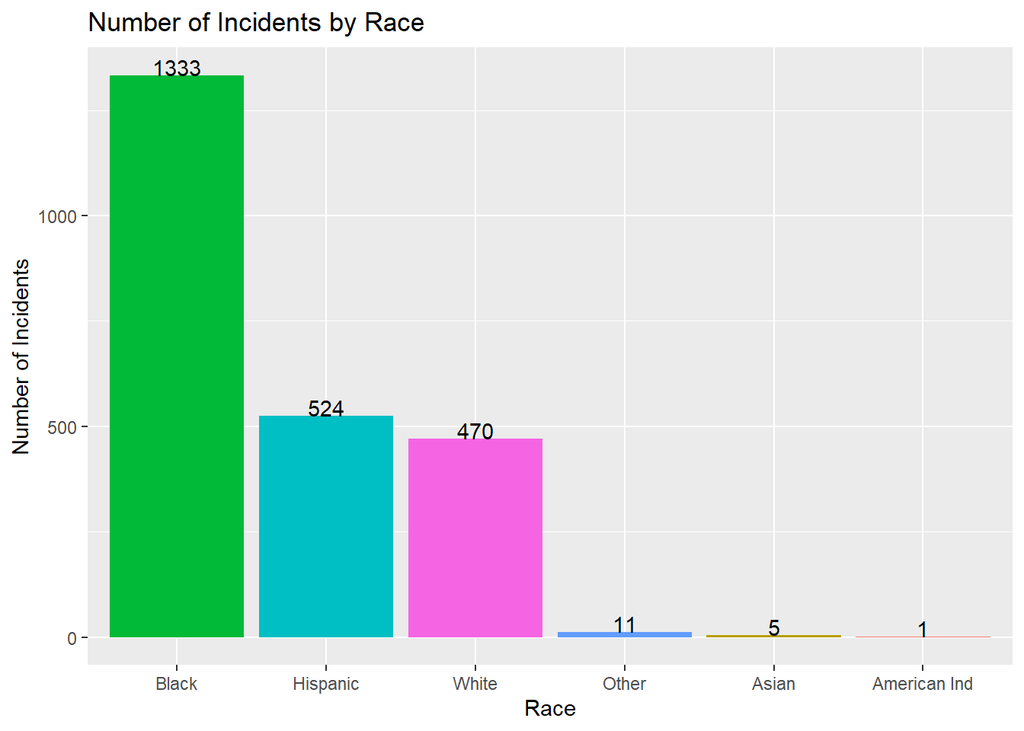

```r
library(ggplot2)
incidents_by_race <- data.frame( table(data$SUBJECT_RACE))
names(incidents_by_race) <- c("Race", "Number of Incidents")
# Removing NULL Race from incidents_by_race data frame
incidents_by_race = incidents_by_race[-5,]
ggplot(data=incidents_by_race, aes(x=reorder( Race, -`Number of Incidents`), y=`Number of Incidents`, fill=Race)) +
  geom_bar(stat="identity") +
  geom_text(aes(label=`Number of Incidents`), vjust=0) +
  labs(x="Race", y="Number of Incidents", title="Number of Incidents by Race") +
   theme(legend.position = "none")
```

This indicates that Black individuals were involved in the highest number of incidents of police use of force, which is concerning and indicative of potential racial bias in policing practices. Further analysis is needed to understand why this disparity exists.

### Top 5 Frequency of subject Offences/crimes

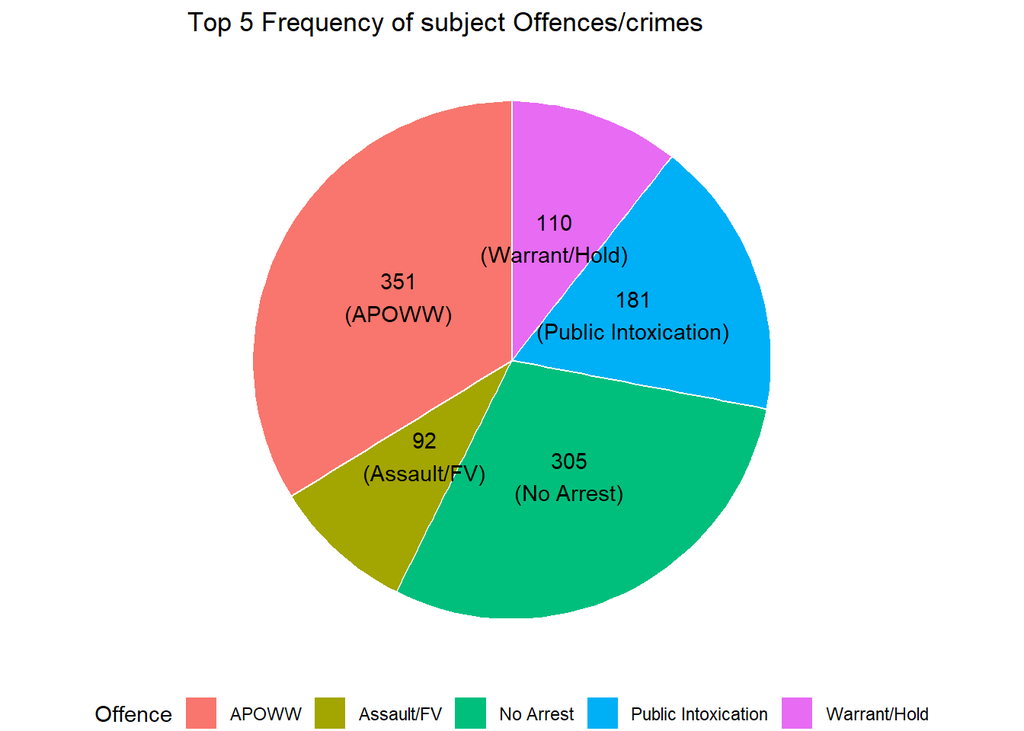

```r
subject_offence_frequency = data.frame (table(data$SUBJECT_OFFENSE))
# Sort the data frame by the 'SUBJECT_OFFENSE' column in descending order
pie_data = subject_offence_frequency[order(-subject_offence_frequency$Freq), ]
names(pie_data) <- c("Offence", "Frequency")

#get top 5
pie_data = pie_data[1:5,]

# Calculate the total frequency
total <- sum(pie_data$Frequency )

# Create the pie chart
ggplot(pie_data, aes(x="", y=Frequency, fill=Offence)) +
  geom_bar(stat="identity", width=1, color="white") +
  coord_polar("y", start=0) +
  theme_void() +
  theme(legend.position = "bottom") +
  geom_text(aes(label = paste0( Frequency,"\n(" ,Offence, ")" )), position = position_stack(vjust = 0.5)) +
  labs(title = "Top 5 Frequency of subject Offences/crimes", fill = "Offence", x = NULL, y = NULL)
```

### Number of Offences/crimes by Hours, weekdays and months

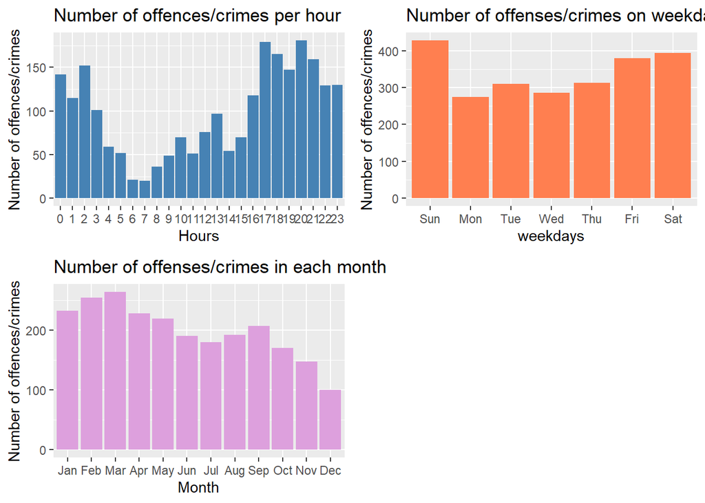

```r
offences_by_hour_frequency = data.frame( table(data$hours))
colnames(offences_by_hour_frequency) = c("hours","Freq")
hour_plot <- ggplot(data=offences_by_hour_frequency,aes(x=hours,y=Freq)) + geom_bar(stat="identity", fill="steelblue") +
  xlab("Hours") +
  ylab("Number of offences/crimes") +
ggtitle("Number of offences/crimes per hour")



offences_by_weekdays_frequency = data.frame(table(data$weekdays))
colnames(offences_by_weekdays_frequency) = c("weekdays","Freq")
offences_by_weekdays_frequency$weekdays <- factor(offences_by_weekdays_frequency$weekdays,
                 levels = c("Sun", "Mon", "Tue", "Wed", "Thu", "Fri", "Sat"))
weekday_plot <- ggplot(data=offences_by_weekdays_frequency,aes(x=weekdays,y=Freq)) + geom_bar(stat="identity", fill="coral") +
  xlab("weekdays") +
  ylab("Number of offences/crimes") +
  ggtitle("Number of offenses/crimes on weekdays")


offences_on_each_month = data.frame(table(data$month_name))
colnames(offences_on_each_month) = c("month","Freq")
offences_on_each_month$month <- factor(offences_on_each_month$month,
                                                  levels = c("Jan", "Feb", "Mar", "Apr", "May", "Jun", "Jul", "Aug", "Sep", "Oct", "Nov", "Dec"))
each_month_plot <- ggplot(data=offences_on_each_month,aes(x=month,y=Freq)) +
  geom_bar(stat="identity", fill="plum") +
  xlab("Month") +
  ylab("Number of offences/crimes") +
  ggtitle("Number of offenses/crimes in each month")
library(gridExtra)

grid.arrange(hour_plot, weekday_plot, each_month_plot, ncol = 2, nrow = 2)
```

We can see that most crimes are committed at night and in the evening. There is a peak in crime during the weekend, particularly on Sundays and Saturdays. This could be because more people go out for outings during the weekend, which may cause a rise in the number of crimes.

### Number of crimes/offences per month in each division

```r
library(dplyr)
```

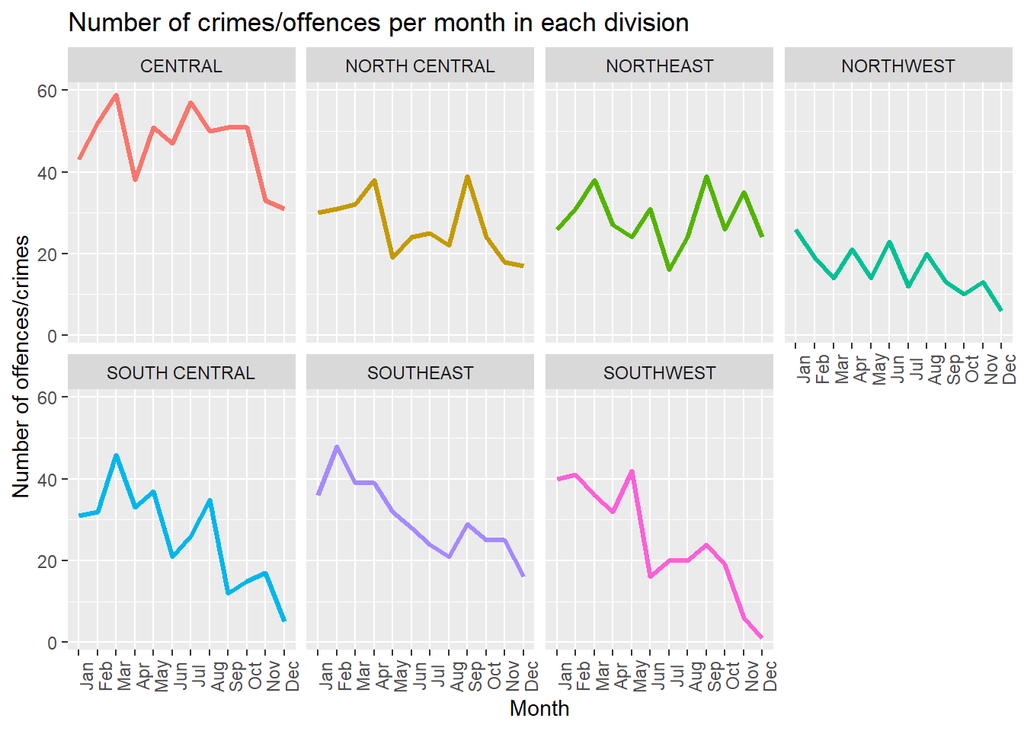

```r
df_data <- data %>%
  count(month_name, DIVISION, name = "freq")

df_data = df_data[!is.na(df_data$month_name), ]
df_data$month_name <- factor(df_data$month_name, levels = c("Jan", "Feb", "Mar", "Apr", "May", "Jun", "Jul", "Aug", "Sep", "Oct", "Nov", "Dec"))


ggplot(df_data, aes(x = month_name, y = freq, color = DIVISION, group = DIVISION)) +
  geom_line(size = 1.2) +
  facet_wrap(~ DIVISION, ncol = 4) +
  labs(x = "Month") +
  labs( y = "Number of offences/crimes") +
  labs(title = "Number of crimes/offences per month in each division") +
  theme(legend.position = "none", axis.text.x = element_text(angle = 90))
```

### Top 6 Forces used on different races

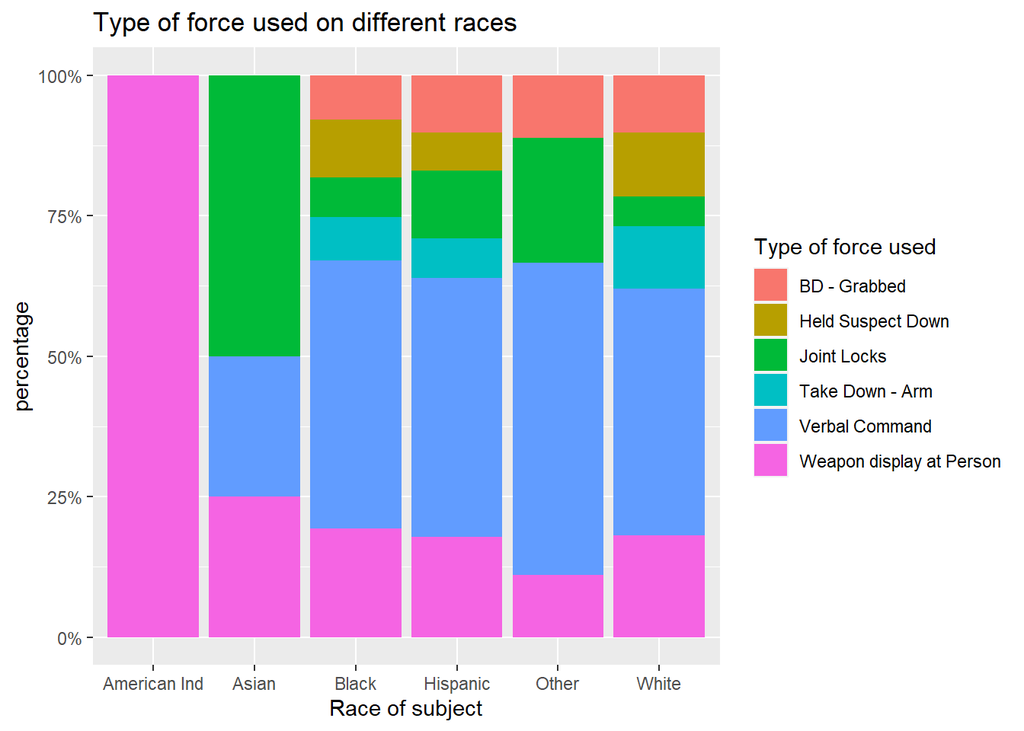

```r
type_of_force_df = data.frame(table(data$TYPE_OF_FORCE_USED1))
type_of_force_df = type_of_force_df[order(-type_of_force_df$Freq), ]
colnames(type_of_force_df) = c("Force_type", "Freq")
type_of_force_df = type_of_force_df[1:6,]




forced_on_races_dataframe = subset(data, SUBJECT_RACE!="NULL" & (TYPE_OF_FORCE_USED1 %in%type_of_force_df$Force_type))
ggplot(forced_on_races_dataframe, aes(x = SUBJECT_RACE, y=10, fill = TYPE_OF_FORCE_USED1)) +
  geom_bar(stat = "identity", position = "fill")+
  scale_y_continuous(labels = scales::percent) +
  xlab("Race of subject") +
  ylab("percentage") +
  guides(fill=guide_legend(title="Type of force used"))+
  ggtitle("Type of force used on different races")
```

According to records, weapon display is the most commonly used force against individuals of American Indian race because it is the only offense recorded for that race. Verbal commands are more frequently used on Black, Hispanic, and other races as well as white individuals. The second most common use of force is weapon display at person.

### Number of crimes in Divisions

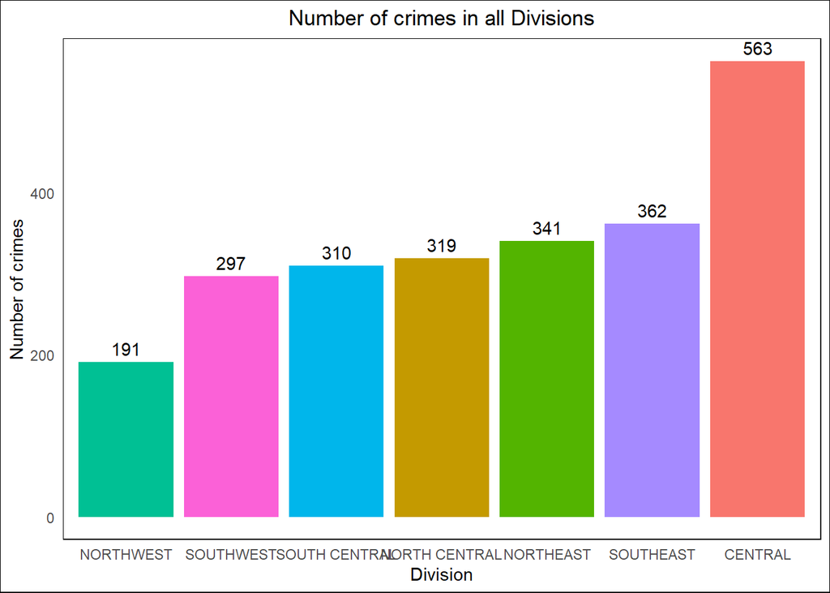

```r
division_freq =  data.frame( table(data$DIVISION))
colnames(division_freq) = c("Division", "Freq")

ggplot(data = division_freq, aes(x =reorder(  Division , Freq), y = Freq, fill = Division)) +
  geom_bar(stat = "identity", position = "dodge") +
  geom_text(aes(label = Freq), vjust = -0.5, position = position_dodge(width = 0.9)) +
  labs(title = "Number of crimes in all Divisions", x = "Division", y = "Number of crimes") +
  theme_minimal() +
  theme(
    legend.position = "none",
    panel.border = element_rect(color = "black", fill = NA),
    panel.grid.major = element_blank(),
    panel.grid.minor = element_blank(),
    plot.title = element_text(hjust = 0.5),
    plot.background = element_rect(fill = "white")
  )
```

We can see that the highest frequency is in the Central Division with a count of 563, followed by Southeast Division with a count of 362. The lowest frequency is in the Northwest Division with a count of 191. The chart shows that the Central and Southeast Divisions require more attention, as they have a higher frequency compared to other divisions.

### The race of individuals and the cause of their arrest

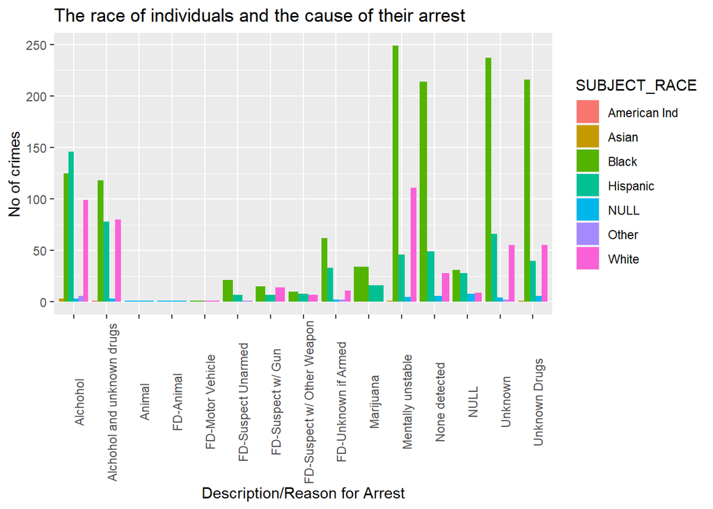

```r
library(dplyr)
data_count <- count(data, SUBJECT_DESCRIPTION , SUBJECT_RACE)

ggplot(data_count, aes(x = SUBJECT_DESCRIPTION, y = n, fill = SUBJECT_RACE )) +
  geom_bar(position = "dodge", stat = "identity") +
  labs(title="The race of individuals and the cause of their arrest", x="Description/Reason for Arrest", y="No of crimes") +
  theme(axis.text.x = element_text(angle = 90))
```

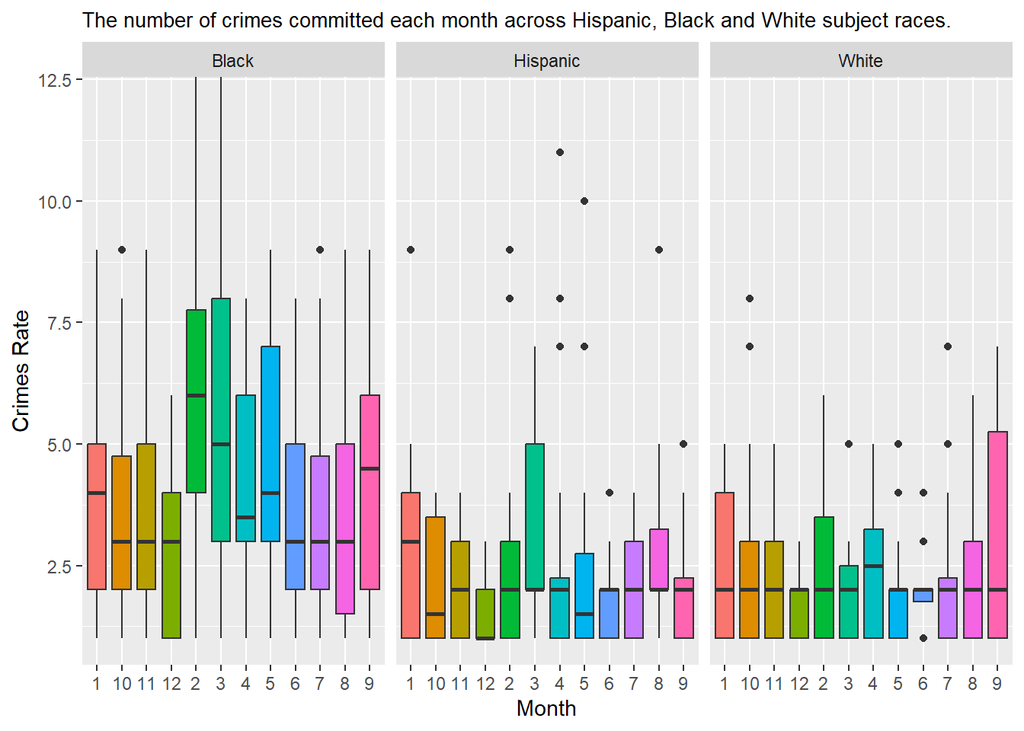

```r
data$month_numbers <- match(data$month_name, month.abb, nomatch = 0)
df <- data   %>%
  filter(SUBJECT_RACE == "Hispanic"  | SUBJECT_RACE == "Black" | SUBJECT_RACE == "White" ) %>%
  group_by(INCIDENT_DATE,month_numbers,SUBJECT_RACE) %>%
  summarize(avg =n(),.groups = "drop")
df <- subset(df, month_numbers != 0 )
df$INCIDENT_DATE = as.Date(df$INCIDENT_DATE)
df$month_numbers = as.character(df$month_numbers)
df$SUBJECT_RACE = as.factor(df$SUBJECT_RACE)
df$avg = as.numeric(df$avg)

ggplot(df , aes(x = (month_numbers), y= avg, fill = month_numbers)) +

      geom_boxplot() +
      labs(x= 'Month') +
      labs(y = 'Crimes Rate') +
      labs(title = paste("The number of crimes committed each month across Hispanic, Black and White subject races.")) +
    theme(plot.title = element_text(size = 10)) +
  theme(legend.position="none") + facet_wrap(~SUBJECT_RACE)  +
    coord_cartesian(ylim = c(1, 12))
```

## Conslusion

The dataset shows concerning disparities in police use of force among different races, with Black individuals involved in the highest number of incidents. APOWW is the most frequent offense recorded. Most crimes occur at night and on weekends. The Central and Southeast Divisions require more attention. Crimes are disproportionately concentrated among Black subjects, and those described as “Mentally unstable,” “None detected,” and “Unknown” account for a significant proportion of crimes.

## References

R Graph Gallery. (n.d.). R Graph Gallery. https://r-graph-gallery.com/

STHDA. (n.d.). ggplot2 barplots: Quick start guide - R software and data visualization. Retrieved March 24, 2023, from http://www.sthda.com/english/wiki/ggplot2-barplots-quick-start-guide-r-software-and-data-visualization